# Analysis for book figures

Julia Wrobel

2022-05-26

# Overview

This file loads produces Figures and runs analysis using the real data.

```r
library(tidyverse)
library(VectraPolarisData)
library(ggridges)
library(MASS)
library(pscl)
library(patchwork)
library(viridis)
library(mxnorm)

#library(data.table)
library(Rtsne)
library(Rphenograph)
library(spatstat)

knitr::opts_chunk$set(echo = TRUE,
  warning = FALSE,
  message = FALSE,
  fig.width = 9,
  fig.height = 4,
  fig.path = './figs/'
)

theme_set(theme_bw() + theme(legend.position = "bottom"))
```

# Install and load data

The data is publicly available on Bioconductor as the package `VectraPolarisData`. You can install it here:

```r
if (!requireNamespace("BiocManager", quietly = TRUE)) {
     install.packages("BiocManager")
}

BiocManager::install("VectraPolarisData")
```

## Ovarian data

Converting the ovarian cancer dataset from a `SpatialExperiment` object to a dataframe.

```r
library(VectraPolarisData)
spe_ovarian <- HumanOvarianCancerVP()

## Assays slots
assays_slot <- assays(spe_ovarian)
intensities_df <- assays_slot$intensities
nucleus_intensities_df<- assays_slot$nucleus_intensities
rownames(nucleus_intensities_df) <- paste0("nucleus_", rownames(nucleus_intensities_df))
membrane_intensities_df<- assays_slot$membrane_intensities
rownames(membrane_intensities_df) <- paste0("membrane_", rownames(membrane_intensities_df))

# colData and spatialData
colData_df <- colData(spe_ovarian)
spatialCoords_df <- spatialCoords(spe_ovarian)

# clinical data
patient_level_ovarian <- metadata(spe_ovarian)$clinical_data %>%
  # create binary stage variable
  dplyr::mutate(stage_bin = ifelse(stage %in% c("1", "2"), 0, 1))

cell_level_ovarian <- as.data.frame(cbind(colData_df,
                                     spatialCoords_df,
                                     t(intensities_df),
                                     t(nucleus_intensities_df),
                                     t(membrane_intensities_df))
                               ) %>%
  dplyr::rename(cd19 = cd19_opal_480,
                cd68 = cd68_opal_520,
                cd3 = cd3_opal_540,
                cd8 = cd8_opal_650,
                ier3 = ier3_opal_620,
                pstat3 = p_stat3_opal_570,
                ck = ck_opal_780,
                ki67 = ki67_opal_690) %>%
  dplyr::select(contains("id"), tissue_category, contains("phenotype"),
                contains("position"), ck:dapi)


# data frame with clinical characteristics where each row is a different cell
#ovarian_df <- full_join(patient_level_ovarian, cell_level_ovarian, by = "sample_id")

rm(spe_ovarian, assays_slot, intensities_df, nucleus_intensities_df, membrane_intensities_df, colData_df, spatialCoords_df)
```

## Lung data

```r
spe_lung <- HumanLungCancerV3()

## Assays slots
assays_slot <- assays(spe_lung)
intensities_df <- assays_slot$intensities
nucleus_intensities_df<- assays_slot$nucleus_intensities
rownames(nucleus_intensities_df) <- paste0("nucleus_", rownames(nucleus_intensities_df))
membrane_intensities_df<- assays_slot$membrane_intensities
rownames(membrane_intensities_df) <- paste0("membrane_", rownames(membrane_intensities_df))

# colData and spatialData
colData_df <- colData(spe_lung)
spatialCoords_df <- spatialCoords(spe_lung)

# clinical data
patient_level_lung <- metadata(spe_lung)$clinical_data

cell_level_lung <- as_tibble(cbind(colData_df,
                                     spatialCoords_df,
                                     t(intensities_df),
                                     t(nucleus_intensities_df),
                                     t(membrane_intensities_df))
                               )   %>%
  dplyr::rename(cd19 = cd19_opal_650,
                cd3 = cd3_opal_520,
                cd14 = cd14_opal_540,
                cd8 = cd8_opal_620,
                hladr = hladr_opal_690,
                ck = ck_opal_570)



# data frame with clinical characteristics where each row is a different cell
#lung_df <- full_join(patient_level_lung, cell_level_lung, by = "slide_id")

rm(spe_lung, assays_slot, intensities_df, nucleus_intensities_df, membrane_intensities_df, colData_df, spatialCoords_df)
```

# Normalization

As an illustrative example will use the `mxnorm` package to normalize the lung data.

## Setting up `mx_dataset` object

Use `slide_id` as slide identifier - Use `sample_id` as image identifier - Use the following marker columns: - `cd19` - `cd14` - `cd3` - `cd8` - `hladr` - `ck` - `dapi` - Use `tissue_category` as a metadata column

```r
mx_data = mx_dataset(data = cell_level_lung,
                     slide_id = "slide_id",
                     image_id = "sample_id",
                     marker_cols = c("cd19",
                                     "cd3",
                                     "cd14",
                                     "cd8",
                                     "hladr",
                                     "ck",
                                     "dapi"
                                     ),
                     metadata_cols = c("tissue_category", "phenotype_ck", "phenotype_cd8", "phenotype_cd14",
                                       "phenotype_other", "phenotype_cd19"))



summary(mx_data)
```

[output not shown]

And let’s look at the data object we’re going to use going forward:

```r
knitr::kable(head(mx_data$data))  %>%
    kableExtra::kable_styling() %>% kableExtra::scroll_box(width = "100%")
```

| slide_id | sample_id | cd19 | cd3 | cd14 | cd8 | hladr | ck | dapi | tissue_category | phenotype_ck | phenotype_cd8 | phenotype_cd14 | phenotype_other | phenotype_cd19 |
| --- | --- | --- | --- | --- | --- | --- | --- | --- | --- | --- | --- | --- | --- | --- |
| #01 0-889-121 | #01 0-889-121 P44_[40864,18015].im3 | 0.201 | 0.025 | 0.155 | 0.132 | 0.115 | 1.024 | 5.166 | Tumor | CK- | CD8- | CD14- | Other- | CD19- |
| #01 0-889-121 | #01 0-889-121 P44_[40864,18015].im3 | 0.546 | 0.172 | 1.799 | 0.821 | 0.239 | 0.721 | 7.477 | Stroma | CK- | CD8- | CD14- | Other- | CD19- |
| #01 0-889-121 | #01 0-889-121 P44_[40864,18015].im3 | 1.388 | 0.060 | 0.173 | 0.989 | 0.268 | 0.391 | 8.237 | Stroma | CK- | CD8- | CD14- | Other- | CD19- |
| #01 0-889-121 | #01 0-889-121 P44_[40864,18015].im3 | 0.683 | 0.004 | 1.136 | 0.174 | 0.245 | 0.468 | 3.786 | Stroma | CK- | CD8- | CD14- | Other- | CD19- |
| #01 0-889-121 | #01 0-889-121 P44_[40864,18015].im3 | 0.176 | 0.034 | 0.176 | 0.191 | 0.127 | 1.608 | 6.055 | Tumor | CK+ | CD8- | CD14- | Other- | CD19- |
| #01 0-889-121 | #01 0-889-121 P44_[40864,18015].im3 | 0.179 | 0.052 | 0.227 | 0.227 | 0.136 | 1.147 | 12.131 | Tumor | CK+ | CD8- | CD14- | Other- | CD19- |

## Normalize using `mx_normalize()`

Normalize using two methods: `log10`, and `mean_divide`. Then, calculate Otsu discordance metrics.

```r
mx_norm = mx_normalize(mx_data,
                       transform = "log10_mean_divide",
                       method = "None")


# Otsu
mx_norm = run_otsu_discordance(mx_norm,
                            table="both",
                            thresold_override=NULL,
                            plot_out = FALSE)

# umap
mx_norm = run_reduce_umap(mx_norm,
                          table="both",
                          marker_list = mx_data$marker_cols,
                          downsample_pct = .1,
                          metadata_cols = mx_data$metadata_cols)
```

Summary table that calculates the metrics from the Bioinformatics paper is printed below

```r
# calculate metrics for unnormalized and normalized data
summary(mx_norm)
```

```
## Call:
## `mx_dataset` object with 153 slide(s), 7 marker column(s), and 6 metadata column(s)
##
## Normalization:
## Data normalized with transformation=`log10_mean_divide` and method=`None`
##
## Anderson-Darling tests:
##       table mean_test_statistic mean_std_test_statistic mean_p_value
##  normalized             478.249                  34.932            0
##         raw            1064.311                  97.682            0
##
## Threshold discordance scores:
##       table mean_discordance sd_discordance
##  normalized            0.039          0.048
##         raw            0.098          0.103
##
## Clustering consistency (UMAP):
##       table adj_rand_index cohens_kappa
##  normalized          0.007        0.000
##         raw          0.010       -0.001
```

## Plotting

First, density plots. Only showing density plots for unnormalized cells for two types of immune markers and 3 subjects.

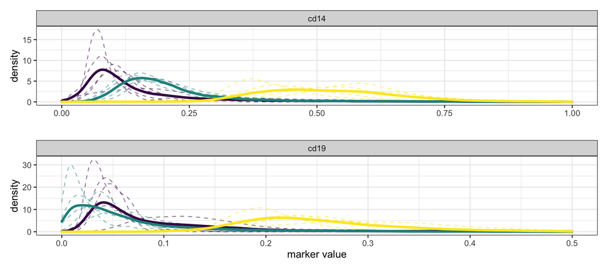

```r
set.seed(103001)
ids = sample(unique(cell_level_lung$slide_id), 3)
markers = c("cd19", "cd14")
mx_df = mx_data$data %>%
  pivot_longer(cd19:dapi, names_to = "marker", values_to = "marker_value") %>%
  filter(slide_id %in% ids)


cd14 = mx_df %>%
    filter(marker %in% c("cd14")) %>%
    ggplot() +
  geom_line(stat = "density", aes(marker_value, group = sample_id, color = slide_id),
            alpha=0.5, linetype = 2) +
    geom_density(aes(marker_value, group = slide_id,
                   color = slide_id), size = 1.25) +
  scale_color_viridis(discrete = TRUE) +
  facet_wrap(~marker, scales = "free", ncol = 1) +
  theme(legend.position = "none") +
  xlim(0, 1) +
  labs(x = "")


cd19 = mx_df %>%
  filter(marker %in% c("cd19")) %>%
  ggplot() +
  geom_line(stat = "density", aes(marker_value, group = sample_id, color = slide_id),
            alpha=0.5, linetype = 2) +
    geom_density(aes(marker_value, group = slide_id,
                   color = slide_id), size = 1.25) +
  scale_color_viridis(discrete = TRUE) +
  facet_wrap(~marker, scales = "free", ncol = 1) +
  theme(legend.position = "none") +
  xlim(0, 0.5) +
  labs(x = "marker value")

cd14 / cd19
```

Discordance plots. Show for subset of markers and maybe subset of subjects.

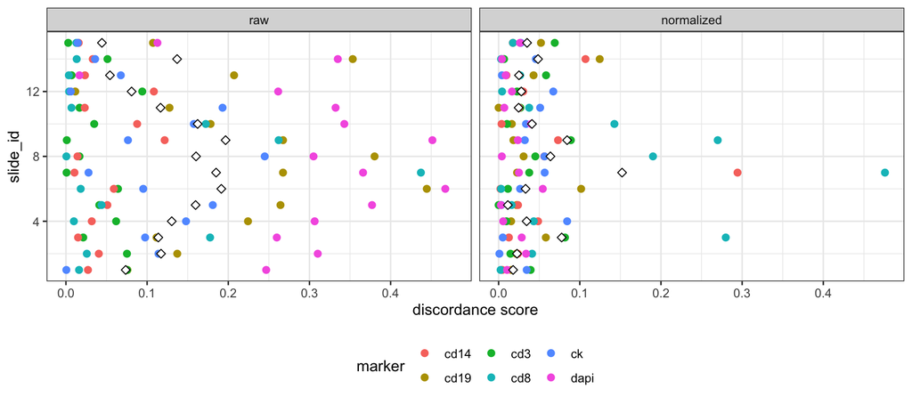

```r
set.seed(103001)
ids = sample(unique(cell_level_lung$slide_id), 15)

otsu_data = mx_norm$otsu_data %>%
  filter(marker %in% c("cd14", "cd19", "cd8", "cd3", "dapi", "ck"),
         slide_id %in% ids) %>%
  mutate(slide_id = as.numeric(factor(slide_id)),
         norm = factor(table, levels = c("raw", "normalized")))

point_size = 2


mean_vals = otsu_data %>%
  group_by(norm, slide_id) %>%
  summarize(m1 = mean(discordance_score), .groups = "drop")


otsu_data %>%
  ggplot() +
  geom_point(aes(discordance_score, slide_id, color = marker), size = point_size) +
  facet_wrap(~ norm) +
  geom_point(data = mean_vals, aes(m1, slide_id), color = "black", fill = "white",
             shape = 23, size = point_size) +
  labs(x = "discordance score", y = "slide_id")
```

```r
rm(mx_data, mean_vals, otsu_data, discordance_score, ids, markers, point_size, mx_df)
```

# Phenotyping

Add in phenograph plots. Clustering using normalized marker values for a single subject.

Now using normalized marker values

```r
norm_df = mx_norm$norm_data %>%
  filter(slide_id == "#01 0-889-121") %>%
  dplyr::select(cd19, cd3, cd14, cd8, ck, contains("phenotype")) %>%
  mutate(phenotype = case_when(
    phenotype_cd14 == "CD14+" ~ "CD14+",
    phenotype_cd19 == "CD19+" ~ "CD19+",
    phenotype_cd8 == "CD8+" ~ "CD8+",
    phenotype_ck == "CK+" ~ "CK+",
    TRUE ~ "other"
  ))


norm_df = na.omit(norm_df)
norm_df_mat = as.matrix(norm_df[, 1:5])


# tsne
set.seed(234232)
tsne_results = Rtsne(norm_df_mat, dims = 2,check_duplicates = FALSE)
norm_df$tsne1 = tsne_results$Y[,1]
norm_df$tsne2 = tsne_results$Y[,2]

# phenograph
phen_results = Rphenograph(norm_df_mat, k = 100)
```

```
##   Finding nearest neighbors...DONE ~ 0.728 s
##   Compute jaccard coefficient between nearest-neighbor sets...DONE ~ 66.986 s
##   Build undirected graph from the weighted links...DONE ~ 3.275 s
##   Run louvain clustering on the graph ...DONE ~ 5.051 s
##   Return a community class
##   -Modularity value: 0.7898703
##   -Number of clusters: 12
```

```r
norm_df$phenograph_cluster <- factor(membership(phen_results[[2]]))
```

Number of clusters normalize is 12

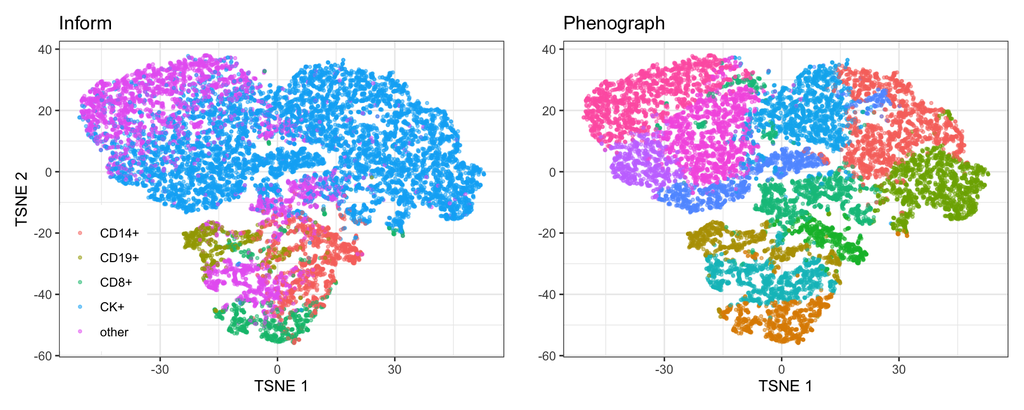

```r
p1 = norm_df %>%
  ggplot(aes(tsne1, tsne2, color = phenotype)) +
  geom_point(alpha = 0.5, size = 0.75) +
  labs(x = "TSNE 1", y = "TSNE 2", title = "Inform") +
  theme(legend.position = c(.1, .25),
        legend.title = element_blank())

p2 = norm_df %>%
  ggplot(aes(tsne1, tsne2, color = phenograph_cluster)) +
  geom_point(alpha = 0.5, size = 0.75) +
  labs(x = "TSNE 1", y = "", title = "Phenograph") +
  theme(legend.position = "none")

p1 + p2
```

# Compositional analysis

Data is currently in cell-level format (each row is a cell). To make it easier for modeling counts and proportions, going to summarize the dataset so that each row is a subject and cell types are reported as counts.

Look at only tumor areas. Also, for “naive” do logit or square root transform, then put it in a linear model

```r
# aggregate to cell counts for each subject
ovarian_counts = cell_level_ovarian %>%
  group_by(sample_id, tissue_category) %>%
  summarize(total_cells = n(),
            cd68_positive_cells = length(phenotype_cd68[phenotype_cd68 == "CD68+"]),
            ki67_positive_cells = length(phenotype_ki67[phenotype_ki67 == "Ki67+"]),
            ck_positive_cells = length(phenotype_ck[phenotype_ck == "CK+"]),
            cd19_positive_cells = length(phenotype_cd19[phenotype_cd19 == "CD19+"]),
            pstat3_positive_cells =
              length(phenotype_p_stat3[phenotype_p_stat3 == "pStat3+"]),
            cd3_positive_cells = length(phenotype_cd3[phenotype_cd3 == "CD3+"]),
            cd8_positive_cells = length(phenotype_cd8[phenotype_cd8 == "CD8+"]),
            cd3plus_cd8plus_cells = length(phenotype_cd8[phenotype_cd8 == "CD8+" &
                                                           phenotype_cd3 == "CD3+"])
            ) %>%
  ungroup()  %>%
  dplyr::select(sample_id, tissue_category, total_cells, cd68_positive_cells, cd19_positive_cells, cd3_positive_cells,
         cd8_positive_cells) %>%
  filter(tissue_category != "Glass") %>%
  pivot_longer(cd68_positive_cells:cd8_positive_cells, names_to = "cell_type", values_to = "count") %>%
  mutate(proportion = count / total_cells,
         sqrt_prop = sqrt(proportion),
         cell_type = factor(cell_type, levels = c("cd3_positive_cells", "cd8_positive_cells",
                                                    "cd19_positive_cells", "cd68_positive_cells"),
                              labels = c("CD4 T cells", "CD8 T cells", "B cells", "Macrophages")))



ovarian_counts = full_join(dplyr::select(patient_level_ovarian, sample_id, stage_bin, BRCA_mutation,
                                         primary, age_at_diagnosis),
                           ovarian_counts, by = "sample_id") %>%
    filter(proportion < 0.75,
         tissue_category == "Tumor") %>%
    mutate(stage_bin = factor(stage_bin, levels = 0:1, labels = c("Stage I/II", "Stage III/IV")),
           BRCA_mutation = factor(BRCA_mutation, levels = 0:1, labels = c("BRCA-", "BRCA+")))
```

## Histograms of cell proportions

```r
# by brca mutation
prop_hists = ovarian_counts %>%
  filter(!is.na(BRCA_mutation)) %>%
  ggplot(aes(proportion,cell_type, fill = cell_type, height = stat(density))) +
  geom_density_ridges(stat = "binline", bins = 15, scale = .95, draw_baseline = FALSE) +
  scale_y_discrete(expand = expansion(add = c(0.05, 0.4))) +
  facet_wrap(~ BRCA_mutation) +
  geom_vline(xintercept = 0, linetype = 2) +
  theme(legend.position = "none",
        axis.title.y = element_blank()) +
  labs(x = "proportion of cells in tumor area", y = "cell type")
```

## Proportions

Calculate raw proportions across cell types:

```r
# ovarian_counts %>%
#   ggplot(aes(proportion)) +
#   geom_histogram() +
#   facet_wrap(~cell_type, nrow = 1, scales = "free")
#
# ovarian_counts %>%
#   ggplot(aes(sqrt_prop)) +
#   geom_histogram() +
#   facet_wrap(~cell_type, nrow = 1, scales = "free")
#
# ovarian_counts %>%
#   mutate(logit_prop = log(proportion + .001)/log(1-(proportion + .001))) %>%
#   ggplot(aes(logit_prop)) +
#   geom_histogram() +
#   facet_wrap(~cell_type, nrow = 1, scales = "free")

# doesn't take into account number of cells in each image. Doesn't let you estimate proportions
mod_lm = lm(sqrt_prop ~ cell_type * BRCA_mutation ,
           data = ovarian_counts)


prop_naive = broom::tidy(mod_lm, conf.int = TRUE) %>%
    filter(grepl("BRCA", term)) %>%
    mutate(cell_type = c("CD4 T cells", "CD8 T cells", "B cells", "Macrophages"),
           model = "naive",
           p = p.value,
           ) %>%
    dplyr::select(cell_type, model, BRCA = estimate, lower = conf.low, upper = conf.high, p)
```

Calculating proportions as a function of BRCA mutation using glms:

```r
# define function to extract proportions and standard deviations for each cell type
get_proportions = function(model, model_name){
  if(model_name %in% c("ZIP","ZINB") ){
    ci = broom:::broom_confint_terms(model) %>%
      filter(grepl("BRCA", term)) %>%
      mutate(term = str_remove(term, "count_"))

    df = left_join(as_tibble(summary(model)$coefficients$count,
                             rownames = "term"),
                  ci) %>%
      janitor::clean_names() %>%
      filter(grepl("BRCA", term)) %>%
      mutate(p = pr_z, cell_type = c("CD4 T cells", "CD8 T cells",
                                     "B cells", "Macrophages"),
           model = model_name) %>%
      dplyr::select(cell_type, model, BRCA = estimate, lower = conf_low,
                    upper = conf_high, p)
      return(df)
  }
  broom::tidy(model, exp = FALSE, conf.int = TRUE) %>%
    filter(grepl("BRCA", term)) %>%
    mutate(cell_type = c("CD4 T cells", "CD8 T cells", "B cells", "Macrophages"),
           model = model_name,
           p = p.value) %>%
    dplyr::select(cell_type, model, BRCA = estimate, lower = conf.low, upper = conf.high, p)
}

# poisson regression
mod_pois = glm(count ~ cell_type * BRCA_mutation  + offset(log(total_cells)),
           family = "poisson",
           data = ovarian_counts)

prop_pois = get_proportions(mod_pois, "Poisson")

# quasi poisson regression
mod_quasipois = glm(count ~ cell_type * BRCA_mutation  + offset(log(total_cells)),
           family = "quasipoisson",
           data = ovarian_counts)

prop_quasipois = get_proportions(mod_quasipois, "quasiPoisson")

# logistic regression
mod_bin = glm(cbind(count, total_cells - count) ~ cell_type * BRCA_mutation,
           family = binomial,
           data = ovarian_counts)

prop_bin = get_proportions(mod_bin, "binomial")

# negative binomial regression
mod_negbin = glm.nb(count ~ cell_type * BRCA_mutation + offset(log(total_cells)),
                    data = ovarian_counts)

prop_negbin = get_proportions(mod_negbin, "negbinomial")

# zero inflated poisson?
mod_zeroinfl <- zeroinfl(count ~ cell_type * BRCA_mutation + offset(log(total_cells)) | 1,
               dist = "poisson",
               data = ovarian_counts)


prop_zeroPois = get_proportions(mod_zeroinfl, "ZIP")

#model = mod_zeroinfl
#model_name = "ZIP"

# zero inflated negbin
mod_zeroNegBin <- zeroinfl(count ~ cell_type * BRCA_mutation  + offset(log(total_cells)) | 1,
               dist = "negbin",
               data = ovarian_counts)

prop_zeroNegBin = get_proportions(mod_zeroNegBin, "ZINB")


## combine results
# make some other more informative and prettier plots. These p-values are super significant.
prop_df = bind_rows(prop_naive, prop_pois, #prop_quasipois,
                    prop_bin,
                    prop_negbin,prop_zeroPois, prop_zeroNegBin) %>%
  #filter(model != "naive") %>%
  mutate(model = factor(model, levels = c("naive", "binomial", "Poisson",
                                          #"quasiPoisson",
                                          "negbinomial", "ZIP", "ZINB")),
         p_sig = ifelse(p <= .05, "*", ""))
```

Plotting

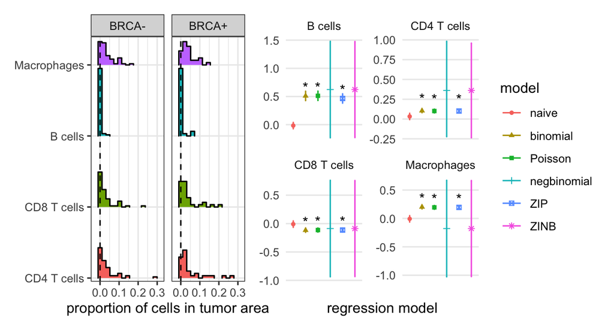

```r
brca_mod = prop_df %>%
  ggplot(aes(model, BRCA, color = model, shape = model)) +
  geom_point(position = position_dodge(width = 0.3), size = 1.25) +
  geom_errorbar(aes(ymin = lower, ymax = upper),
                position = position_dodge(width = 0.3), width = .1) +
  geom_text(aes(label = p_sig), color = "black", nudge_y = .15) +
  theme_minimal() +
  theme(axis.text.x = element_blank(),
        axis.ticks.x = element_blank(),
        axis.title.y = element_blank(),
        panel.grid.minor = element_blank(),
        panel.grid.major.x = element_blank(),
        legend.position = "right") +
  facet_wrap(~cell_type, scales = "free") +
  labs(x = "regression model")

prop_hists + brca_mod + plot_layout(widths = c(1, 1.25))
```

# Spatial analysis

Calculate Ripley’s K for B cells, then B-cells and Macrophages. What should you do about images that don’t have any of a certain cell type?

- Analysis performed using spatstat
- Analyze with survival outcome and make K-M curve
- Need to calculate K for each subject separately. Choosing an arbitrary threshold for `r`. Looking at K-function for all immune cells in the tumor area.

```r
 ripleys_k = function(data){
   ppp_obj = ppp(data$cell_x_position, data$cell_y_position,
                 range(data$cell_x_position),
                 range(data$cell_y_position))

   k_obj = Kest(ppp_obj, r = c(0, 100, 200), correction = "Ripley")

   return(k_obj$iso[which(k_obj$r == 100)])
 }


k_df = cell_level_ovarian %>%
     filter(tissue_category == "Tumor",
            phenotype_cd19 == "CD19+" | phenotype_cd8 == "CD8+" |
              phenotype_cd3 == "CD3+" | phenotype_cd68 == "CD68+")  %>%
  group_by(sample_id) %>%
  group_modify(~ tibble::enframe(ripleys_k(.), name = NULL)) %>%
  ungroup() %>%
  dplyr::rename(k = "value")
```

Calculated Ripley’s K for immune cells. Pick high and low K subject, plot

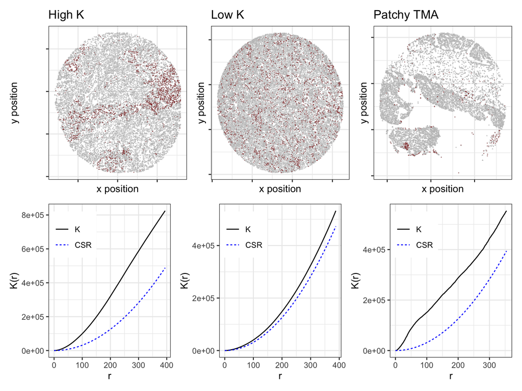

```r
plot_k = function(id, title = ""){
  df = cell_level_ovarian %>%
  filter(sample_id == id, tissue_category != "Glass") %>%
    mutate(immune = ifelse(phenotype_cd19 == "CD19+" | phenotype_cd8 == "CD8+" |
              phenotype_cd3 == "CD3+" | phenotype_cd68 == "CD68+", "immune", "other"))

  ppp_obj = ppp(filter(df, immune == "immune")$cell_x_position,
              filter(df, immune == "immune")$cell_y_position,
                 range(filter(df, immune == "immune")$cell_x_position),
                 range(filter(df, immune == "immune")$cell_y_position))

  p1 = df %>%
    ggplot(aes(cell_x_position, cell_y_position)) +
    geom_point(aes(shape = tissue_category),
               size = 0.25, alpha = .8, color = "gray") +
    geom_point(data = filter(df, immune == "immune"),
               size = 0.5, color = "darkred",
               shape = "+") +
    labs(x = "x position", y = "y position", title = title) +
    theme(axis.text = element_blank(), legend.position = "none")

  k_obj = Kest(ppp_obj, correction = "Ripley")
  p2 = tibble(r = k_obj$r,
              K = k_obj$iso,
              CSR = k_obj$theo) %>%
    pivot_longer(K:CSR, names_to = "K", values_to = "value") %>%
    mutate(K = factor(K, levels = c("K", "CSR")),
           color = ifelse(K == "K", "black", "darkred")) %>%
    ggplot(aes(r, value, group = K, linetype = K, color = K)) +
    geom_line() +
    scale_colour_manual(name = "K",values = c("black", "blue")) +
    labs(y = "K(r)") +
    theme(legend.position = c(.2,.8),
          legend.title=element_blank())

  list(p1, p2)

}

high_k = "030120 P9HuP6 TMA 1-B_Core[1,7,E]_[14474,48365].im3"
low_k = "030120 P9HuP6 TMA 1-A_Core[1,6,C]_[10353,49826].im3"
patchy_k = "030120 P9HuP6 TMA 1-A_Core[1,1,C]_[10162,38841].im3"

high = plot_k(high_k, "High K")
low = plot_k(low_k, "Low K")
patchy = plot_k(patchy_k, "Patchy TMA")


(high[[1]] + low[[1]] + patchy[[1]]) / (high[[2]] + low[[2]] + patchy[[2]])
```